# Regresión lineal Multiple

Cristian David Pachacama

1 de Agosto de 2015

### 2.1.- Lectura de archivos

Primero que nada, leemos los archivos `"poblacion1.xlsx"`, `"poblacion2.xlsx"` mediante el codigo:

```r
pobla1<-read_excel("poblacion1.xlsx",sheet=1,na="")
pobla2<-read_excel("poblacion2.xlsx",sheet=1,na="")
```

Ahora mostramos los data frames:

```r
library(DT)
datatable(pobla1)
```

|  | identificador | poblacion | var.pobl.mayor | menores.18 |
| --- | --- | --- | --- | --- |
| 1 | 1001 | 18.7 | 6.2 | 39.7 |
| 2 | 1002 | 13.8 | 7.2 | 10.4 |
| 3 | 1003 | 13.4 | 7.1 | 20.4 |
| 4 | 1004 | 11.4 | 2.6 | 38.7 |
| 5 | 1005 | 10.5 | 2.8 | 36.4 |
| 6 | 1006 | 10.3 | 1.4 | 29.8 |
| 7 | 1007 | 10.3 | -0.5 | 31.8 |
| 8 | 1008 | 10.3 | 3 | 31.1 |
| 9 | 1009 | 10.3 | -1.9 | 15.9 |
| 10 | 1010 | 9.4 | -1.5 | 22.4 |

[output cut: 34 more lines]

```r
datatable(pobla2)
```

|  | identificador | part.almz.escl | var.ingresos | tasa.crimen | var.tasa.crimen | region | serv.bas.compl |
| --- | --- | --- | --- | --- | --- | --- | --- |
| 1 | 1044 | 73.8 | 50.5 | 704.1 | -40.9 | B | SI |
| 2 | 1042 | 34.4 | 24.2 | 179.9 | 12.3 | B | NO |
| 3 | 1010 | 22.2 | 33.5 | 61.5 | -32.7 | A | NO |
| 4 | 1009 | 39.9 | 38.5 | 86.4 | -13.5 | A | SI |
| 5 | 1008 | 51.7 | 26.2 | 42.4 | -31.9 | A | NO |
| 6 | 1007 | 57.2 | 27.2 | 61.2 | -17.6 | A | NO |
| 7 | 1006 | 43.7 | 29.4 | 54 | -10 | A | NO |
| 8 | 1005 | 72.3 | 26 | 77.5 | -21.6 | A | SI |
| 9 | 1004 | 78.2 | 18.4 | 86.6 | -12.8 | A | NO |
| 10 | 1003 | 13.9 | 22.5 | 38.3 | -33.6 | A | NO |

[output cut: 30 more lines]

### 2.2.-Union de archivos

En este item usaremos la funcion `merge()` que nos permite unir dos data frames si poseen una columna comun, lo hacemos mediante el siguiente codigo:

```r
poblacion<-merge(pobla1,pobla2,by="identificador",suffixes=c("",""))
```

Y obtenemos la siguiente data:

|  | identificador | poblacion | var.pobl.mayor | menores.18 | part.almz.escl | var.ingresos | tasa.crimen | var.tasa.crimen | region | serv.bas.compl |
| --- | --- | --- | --- | --- | --- | --- | --- | --- | --- | --- |
| 1 | 1001 | 18.7 | 6.2 | 39.7 | 55.8 | 28.7 | 52.6 | -2.9 | A | SI |
| 2 | 1002 | 13.8 | 7.2 | 10.4 | 57.9 | 26.2 | 111 | -22.6 | A | SI |
| 3 | 1003 | 13.4 | 7.1 | 20.4 | 13.9 | 22.5 | 38.3 | -33.6 | A | NO |
| 4 | 1004 | 11.4 | 2.6 | 38.7 | 78.2 | 18.4 | 86.6 | -12.8 | A | NO |
| 5 | 1005 | 10.5 | 2.8 | 36.4 | 72.3 | 26 | 77.5 | -21.6 | A | SI |
| 6 | 1006 | 10.3 | 1.4 | 29.8 | 43.7 | 29.4 | 54 | -10 | A | NO |
| 7 | 1007 | 10.3 | -0.5 | 31.8 | 57.2 | 27.2 | 61.2 | -17.6 | A | NO |
| 8 | 1008 | 10.3 | 3 | 31.1 | 51.7 | 26.2 | 42.4 | -31.9 | A | NO |
| 9 | 1009 | 10.3 | -1.9 | 15.9 | 39.9 | 38.5 | 86.4 | -13.5 | A | SI |
| 10 | 1010 | 9.4 | -1.5 | 22.4 | 22.2 | 33.5 | 61.5 | -32.7 | A | NO |

[output cut: 30 more lines]

### Diagramas de Cajas e Histogramas

Ahora generamos los diagramas de cajas e histogramas de variables numericas y categoricas respectivamente.

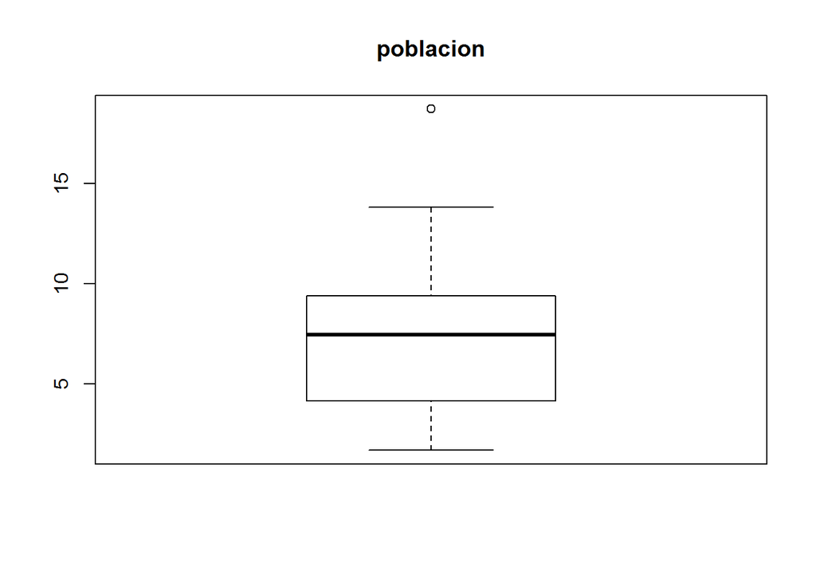

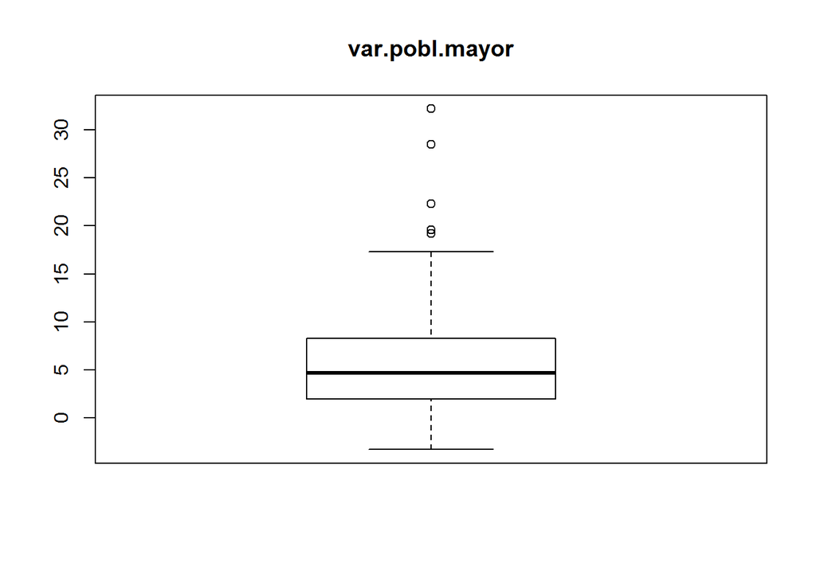

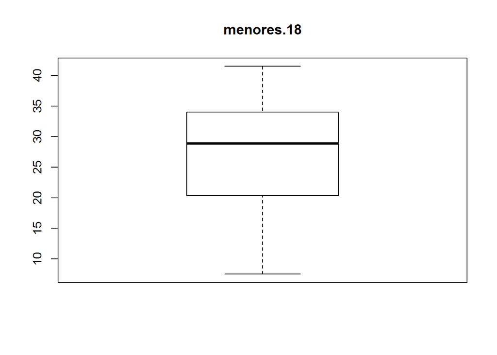

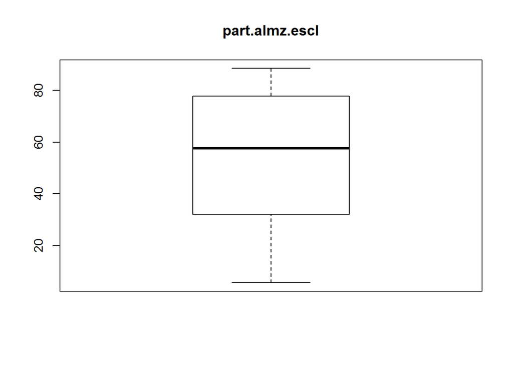

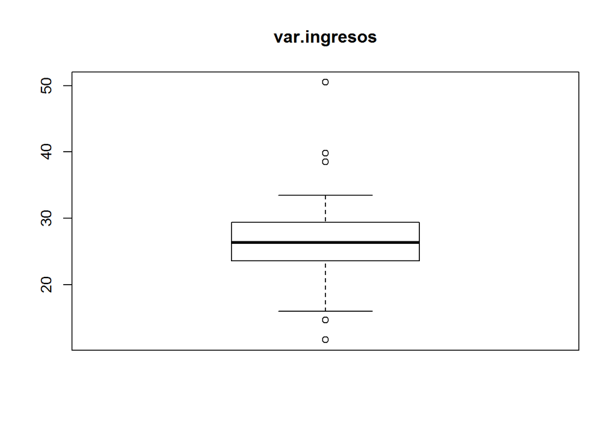

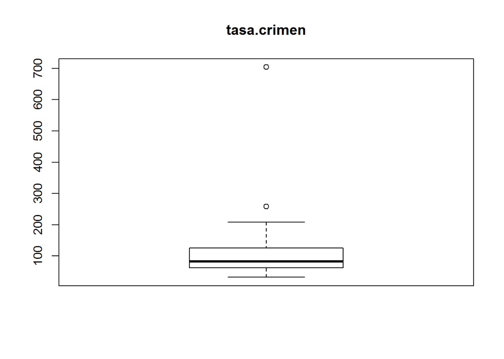

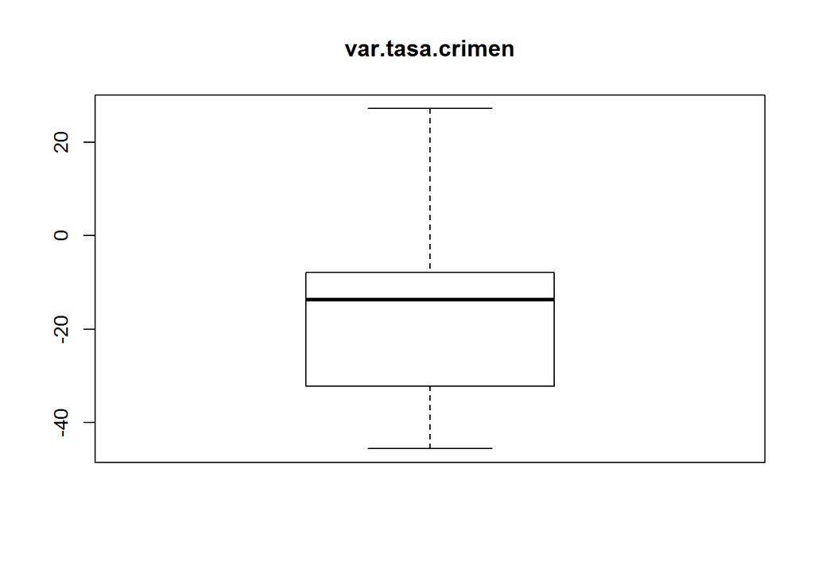

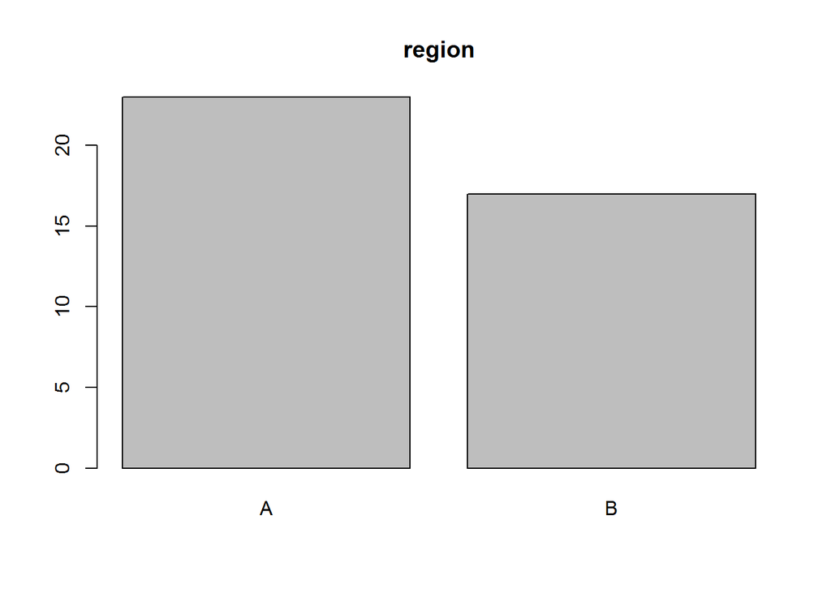

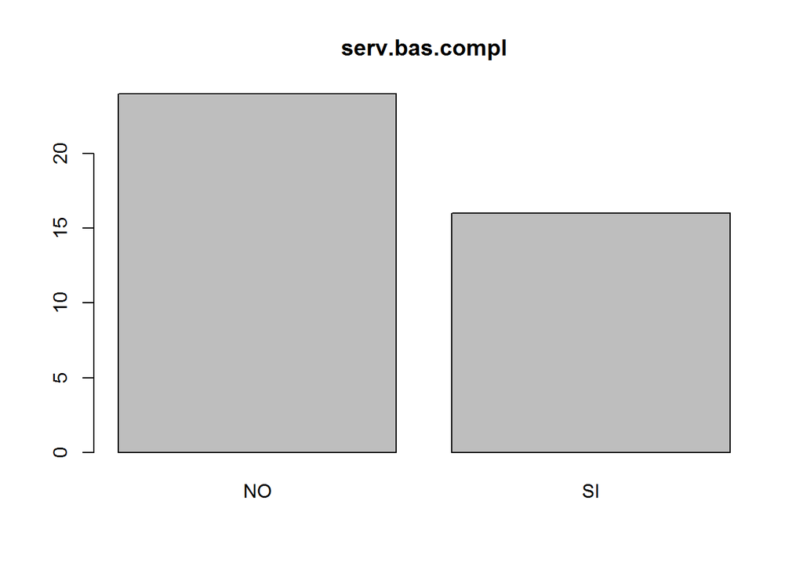

```r
for(j in 2:dim(poblacion)[2]){
    if(is.numeric(poblacion[,j])==TRUE){
      boxplot(poblacion[,j])
      title(names(poblacion)[j])
    }else {
      #if(is.factor(p[,j])==TRUE){
      barplot(table(poblacion[,j]))
      title(names(poblacion)[j])
    }
}
```

### 2.3.- Medidas de dispersion

A continuacion calculamos los maximos, minimos, medias, etc. de las variables numericas, y la frecuencia de variables categoricas.

```r
for(j in 2:dim(poblacion)[2]){
    if(is.numeric(poblacion[,j])==TRUE){
      Clase[j] <- class(poblacion[,j])
      Maximo[j] <- max(poblacion[,j])
      Minimo[j] <- min(poblacion[,j])
      Media[j] <- mean(poblacion[,j])
      Desviacion[j]<-sd(poblacion[,j])
      Primer_Cuantil[j]<- quantile(poblacion[,j],probs=seq(0,1,0.25),na.rm = FALSE)[2]
    }else {

      Clase[j] <- class(poblacion[,j])
      Maximo[j] <- NA
      Minimo[j] <- NA
      Media[j] <- NA
      Desviacion[j] <- NA
      Primer_Cuantil[j] <- NA
      table(poblacion[,j])/dim(poblacion)[1]
    }
}
```

|  | names.poblacion. | Clase | Maximo | Minimo | Media | Desviacion | Primer_Cuantil |
| --- | --- | --- | --- | --- | --- | --- | --- |
| 1 | identificador | 1 | 1 | 1 | 1 | 1 | 1 |
| 2 | poblacion | numeric | 18.7 | 1.7 | 7.2325 | 3.6214027244022 | 4.175 |
| 3 | var.pobl.mayor | numeric | 32.2 | -3.3 | 6.6475 | 8.14877645369584 | 1.975 |
| 4 | menores.18 | numeric | 41.5 | 7.5 | 27.0725 | 9.03633654780123 | 20.375 |
| 5 | part.almz.escl | numeric | 88.5 | 5.7 | 53.175 | 25.4207844499591 | 33.25 |
| 6 | var.ingresos | numeric | 50.5 | 11.7 | 26.7875 | 6.85416540020252 | 23.65 |
| 7 | tasa.crimen | numeric | 704.1 | 32 | 111.035 | 108.88913333742 | 62.325 |
| 8 | var.tasa.crimen | numeric | 27.2 | -45.6 | -15.9625 | 15.7586229956157 | -32.05 |
| 9 | region | character |  |  |  |  |  |
| 10 | serv.bas.compl | character |  |  |  |  |  |

Luego para las variables categoricas, se muestran las frecuencias:

```
##
##     A     B
## 0.575 0.425
```

```
##
##  NO  SI
## 0.6 0.4
```

### 2.4.- Calculo de la correlacion entre la poblacion y las otras variables

Para calcular la correlacion entre la poblacion y el resto de variables numericas usamos el siguiente codigo:

```r
    correlacion <- 3:dim(poblacion)[2]
    correlacion[1] <- NA
for(i in 2:dim(poblacion)[2]){
  if(is.numeric(poblacion[,i])==TRUE){
  correlacion[i] <- cor(poblacion[,2],poblacion[,i])
  } else {
    correlacion[i] <- NA
  }
}
```

|  | names.poblacion. | correlacion |
| --- | --- | --- |
| 1 | identificador |  |
| 2 | poblacion | 1 |
| 3 | var.pobl.mayor | -0.157740307336422 |
| 4 | menores.18 | 0.19709059035665 |
| 5 | part.almz.escl | -0.0468617217051812 |
| 6 | var.ingresos | -0.0767770820467971 |
| 7 | tasa.crimen | -0.374922537800256 |
| 8 | var.tasa.crimen | -0.0764530102296091 |
| 9 | region |  |
| 10 | serv.bas.compl |  |

### 2.5.-Prueba de hipotesis para la diferencia de medias

Se desea conocer si con una confiabilidad de 90% se puede asumir que la media de la variable “poblacion” en el grupo donde serv.bas.compl=SI es distinda a la media del grupo donde serv.bas.compl=NO. Para ello antes de hacer el test (prueba de hipotesis) manipulamos la data “poblacion”

```r
  #Primero modificamos la data, para transformar a "factor las columnas region y serv.bas..." para poder usar el test t(student)
  servicios<-factor(poblacion[,"serv.bas.compl"],levels=c("SI","NO"),labels=c("si","no"))
  region<-factor(poblacion[,"region"],levels=c("A","B"),labels=c("a","b"))
  poblacion_fac<-data.frame(poblacion[,1:7],region,servicios)
```

Luego hacemos un grafico de cajas para observar como se comporta la “poblacion” en los dos grupos.

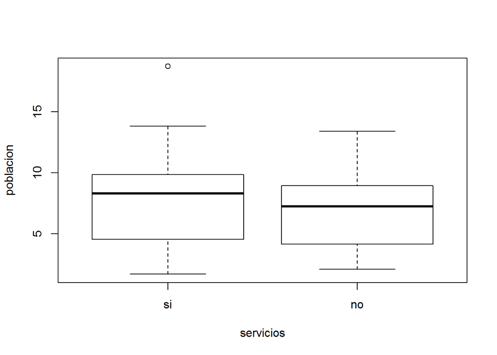

```r
  plot(poblacion ~ servicios , data = poblacion_fac)
```

Y finalmente realizamos la prueba de hipotesis para la diferencia de medias

```r
  prueba<-t.test(poblacion ~ servicios , data = poblacion_fac, conf.level=0.9)
  prueba
```

```
##
##  Welch Two Sample t-test
##
## data:  poblacion by servicios
## t = 0.9199, df = 24.672, p-value = 0.3666
## alternative hypothesis: true difference in means is not equal to 0
## 90 percent confidence interval:
##  -0.9901808  3.2985141
## sample estimates:
## mean in group si mean in group no
##         7.925000         6.770833
```

Como podemos observar el intervalo de confianza para la diferencia de medias es $[ -0.9901808 ; 3.2985141 ]$ Como vemos este intervalo posee al cero. Por lo tanto se acepta que la diferencia de medias es igual a cero.

### 2.6.- Regresion Lineal Multiple

```r
  regre<-lm(poblacion~var.pobl.mayor+menores.18+tasa.crimen,data=poblacion_fac)
```

$\hat{po} = 7.3884361 + 0.0296939 \hat{va} + 0.0394981 \hat{me} + -0.0128125 \hat{ta}$

En la siguiente tabla se reumen los resultados mas importantes de la regresion

```r
  summary(regre)
```

```
##
## Call:
## lm(formula = poblacion ~ var.pobl.mayor + menores.18 + tasa.crimen,
##     data = poblacion_fac)
##
## Residuals:
##     Min      1Q  Median      3Q     Max
## -5.0239 -2.6986 -0.3656  2.0947 10.2333
##
## Coefficients:
##                 Estimate Std. Error t value Pr(>|t|)
## (Intercept)     7.388436   2.048573   3.607 0.000933 ***
## var.pobl.mayor  0.029694   0.082263   0.361 0.720238
## menores.18      0.039498   0.064026   0.617 0.541179
## tasa.crimen    -0.012813   0.006367  -2.012 0.051730 .
## ---
## Signif. codes:  0 '***' 0.001 '**' 0.01 '*' 0.05 '.' 0.1 ' ' 1
##
## Residual standard error: 3.468 on 36 degrees of freedom
## Multiple R-squared:  0.1533, Adjusted R-squared:  0.08277
## F-statistic: 2.173 on 3 and 36 DF,  p-value: 0.1081
```

### 2.7.- Interpretacion del $R^2$

Obtubimos un $R^2=0.1533239$ , lo que quiere decir que la regresion explica el $15.3323897%$ de la variabilidad.

### 2.8 Significancia de la Regresion

Para anaizar la significancia de la regresion nos ayudaremos de la tabla ANOVA

```r
  summary(aov(regre))
```

```
##                Df Sum Sq Mean Sq F value Pr(>F)
## var.pobl.mayor  1   12.7   12.73   1.058 0.3105
## menores.18      1   17.0   16.99   1.412 0.2424
## tasa.crimen     1   48.7   48.70   4.049 0.0517 .
## Residuals      36  433.0   12.03
## ---
## Signif. codes:  0 '***' 0.001 '**' 0.01 '*' 0.05 '.' 0.1 ' ' 1
```

### 2.9 Analisis de Residuos

A continuacion para el analisis de residuos usaremos varios criterios, el primero de ellos es:

#### Grafica poblacion vs residuos

A continuacion se muestra la grafica de dispersion de poblacion vs residuos

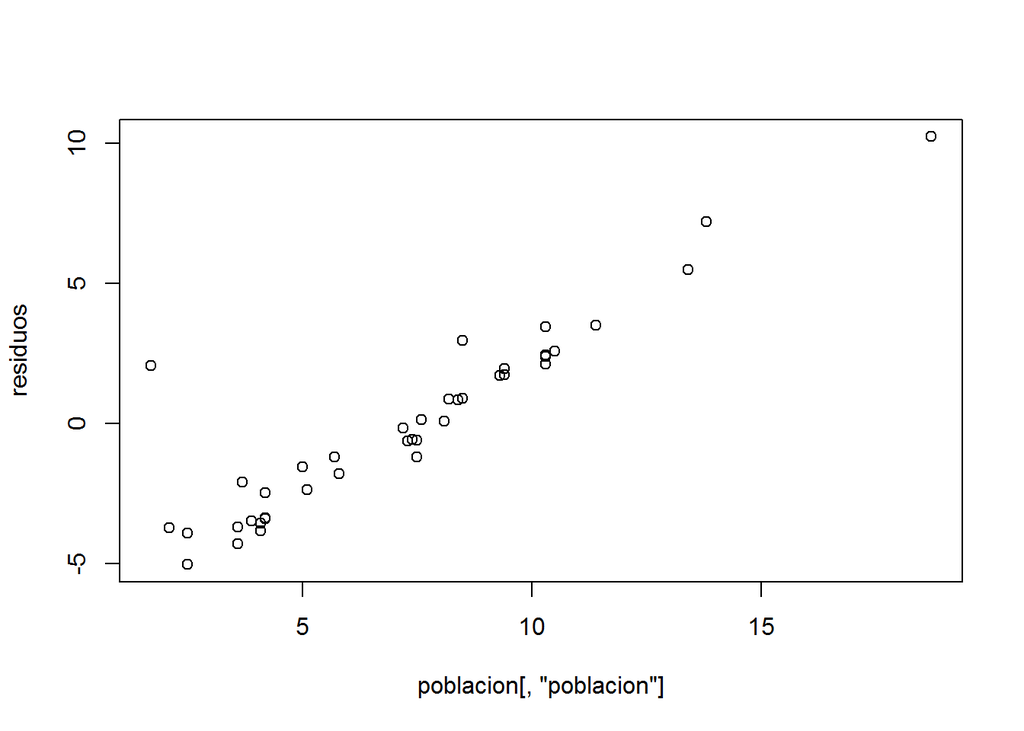

```r
  plot(poblacion[,"poblacion"],residuos)
```

#### Histograma de residuos

Para poder tratar de observar cierta semejanza a la distribucion normal, hacemos el respectivo histograma

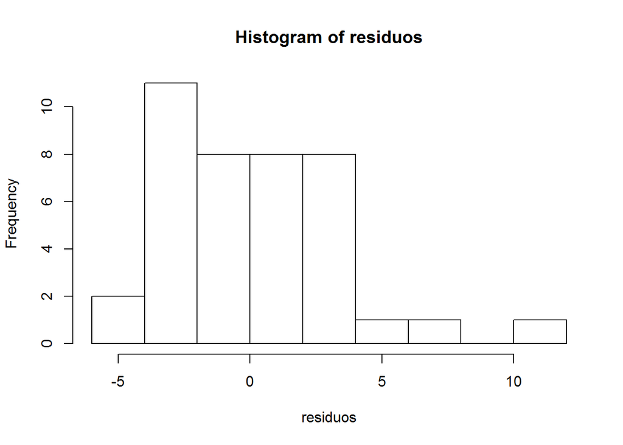

```r
  hist(residuos)
```

#### Comparacion con Cuantiles teoricos

Compararemos a los cuantiles de los residuos, con los cuantiles teoricos de la distribucion normal, esto ayudados de la fucion `qqnorm()`

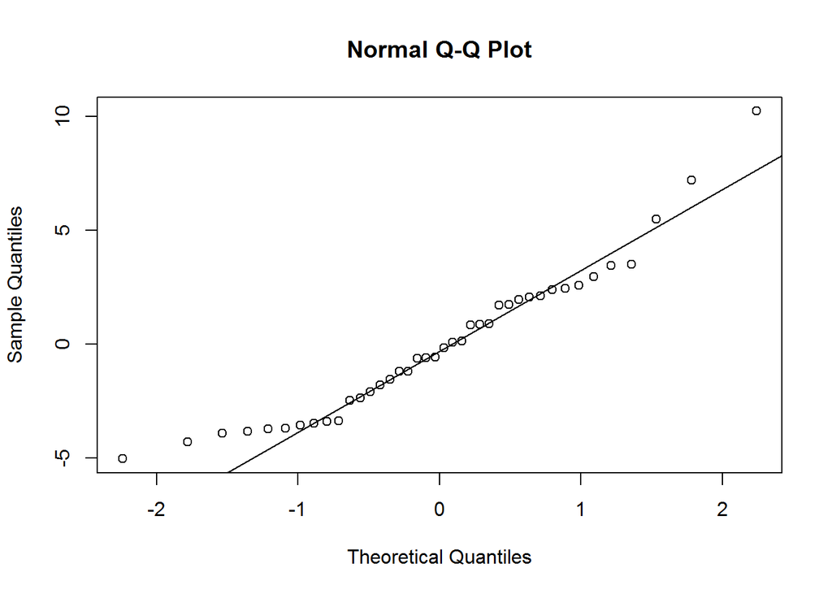

```r
qqnorm(residuos)
qqline(residuos)
```